# Communicate Data Insights Ford GoBikes (Part 2/2)

#### by Dirk Kadijk

#### as Capstone Project in Udacity Data Analyst Nanodegree

1. Investigation overview
2. Dataset overview
3. Key derived insights

# 1. Investigation Overview

This project has two parts that demonstrate the importance and value of data visualization techniques in the data analysis process which is as Capstone project part of the Udacity Data Analysis Nanodegree course.

- In the first part (1/2) I used Python visualization libraries to systematically wrangle and explore the origin `2017-fordgobike-tripdata` datafile, starting from plots of single variables and building up to plots of multiple variables.
- In this second part of the project (2/2), I present the interesting relationships, patterns and insights that I discovered in the (in part 1) selected and cleaned dataset.

# 2. Dataset Overview

The dataset used for this exploratory analysis consists of Bay Wheels's trip data for individual rides made in a bike-sharing system covering the greater San Francisco Bay area from June 28, 2017 to December 31, 2017.

The Dataset consists of anonymized information regarding 519.700 bike trips, including its timing and geolocation of the start and end of each trip.

In the investigation we used mainly the following features in the cleaned datafile `fordgobike-tridata_clean.csv`:

> - user_type (values: “Subscriber” or “Customer”)
> - duration_min (duration of trip in minutes)
> - start_date (date of start of biketrip)
> - start_hour_of_day (hour of start of biketrip)
> - start_day_of_week (day of week of start of biketrip)
> - start_month (month of start of biketrip)

### Cleaning to create cleaned datafile `fordgobike-tridata_clean.csv`:

For safety and to enable bi- and multivariate exploration I removed the outliers with values beyond 5 standard deviations based on calculated Z-score. As a result all observations with bike trip duration_min > 44 minutes were removed.

Further we created several start_variables with different time-resolution (start_hour_of_day, start_day_of_week, start_month).

And corrected some data_types.

# 3. Key derived insights

## 3.1. Distribution of trips between user_types

- Almost 80% of bike trips are done by Subscribers

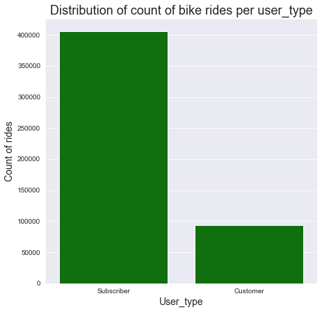

```python
# same distribution in countplot format
plt.figure(figsize=(7,7))


sb.countplot(data=main_new, x='user_type', color='green')
plt.xlabel('User_type', fontsize=14)
plt.ylabel('Count of rides', fontsize=14)
plt.title('Distribution of count of bike rides per user_type', fontsize=18);
```

## 3.2. Distribution of trip duration between user_types

- Bike trip duration has a right skewed distribution for both user_types, however the share (peak) of short trips by Subscribers is relatively high compared with Customers.
- The average bike trip duration of Customers is almost the double of Subscribers (18 vs 10 minutes).

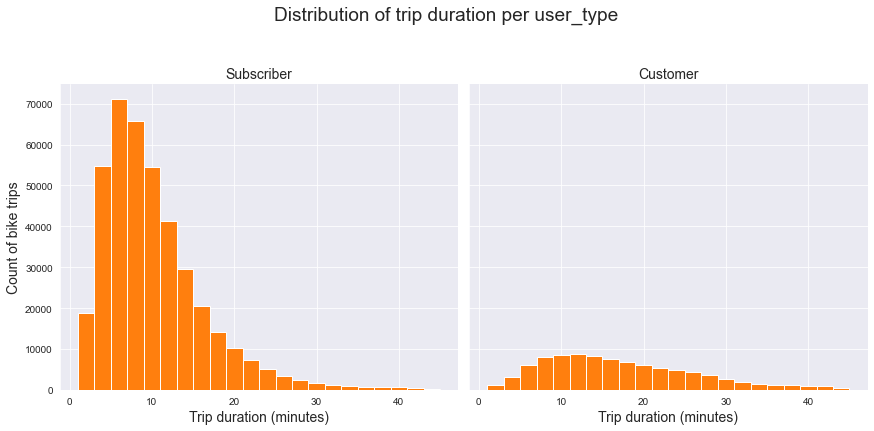

```python
g = sb.FacetGrid(data = main_new, col = 'user_type', col_wrap = 2, height = 6)
base_color = sb.color_palette()[1]

g.map(plt.hist, 'duration_min', bins = np.arange(main_new['duration_min'].min(), main_new['duration_min'].max()+1, 2), color = base_color)
g.set_ylabels('Count of bike trips', size=14)
g.set_xlabels('Trip duration (minutes)', size=14)
g.set_titles('{col_name}', size=14);

plt.subplots_adjust(top=0.8)
g.fig.suptitle('Distribution of trip duration per user_type', fontsize=19);
```

## 3.3. Distribution of bike trips per hour-of-day and day-of-week for each user_type

- For both types of users the distribution of rides during the weekdays depends a lot on the hour of the day and day of the week.
- It is interesting, that Customers tend to use the bike service mostly on Saturday/Sunday from 12 PM to 5 PM, while Subscribers will likely have a trip from Monday to Friday during rush hours (8-9 AM, 17-18 PM).

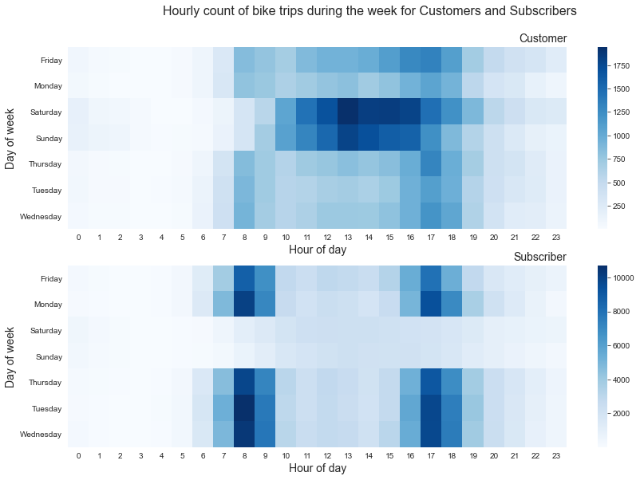

```python
plt.figure(figsize=(14,9))

plt.subplot(2, 1, 1)
customers = main_new.query('user_type == "Customer"')
ct_counts = customers.groupby(['start_day_of_week', 'start_hour_of_day']).size()
ct_counts = ct_counts.reset_index(name='count')
ct_counts = ct_counts.pivot(index='start_day_of_week', columns='start_hour_of_day', values='count')
sb.heatmap(ct_counts, cmap="Blues");
plt.title('Customer', loc='right', fontsize=14);
plt.xlabel('Hour of day', fontsize=14);
plt.ylabel('Day of week', fontsize=14);

plt.subplot(2, 1, 2)
subscribers = main_new.query('user_type == "Subscriber"')
st_counts = subscribers.groupby(['start_day_of_week', 'start_hour_of_day']).size()
st_counts = st_counts.reset_index(name='count')
st_counts = st_counts.pivot(index='start_day_of_week', columns='start_hour_of_day', values='count')
sb.heatmap(st_counts, cmap="Blues");
plt.title('Subscriber', loc='right', fontsize=14);
plt.xlabel('Hour of day', fontsize=14);
plt.ylabel('Day of week', fontsize=14);

plt.subplots_adjust(top=0.9)
plt.suptitle('Hourly count of bike trips during the week for Customers and Subscribers', fontsize=16);
```

## 3.4. Distribution of trip duration by top destination (end_station_name) and start_day_of_week:

- Also location of end destination station matters as variable for predicting bike usage and trip duration.
- We determined the top 10 station names as trip destination.
- The destination `The Embarcadero at Sansome St` has the highest trip duration (about 30-40% higher) compared with other destinations.
  - This has probably a relation with that the station is located at a great tourist/recreation area which ... can make you understand why the bike trips by Customers to this station take long... :)

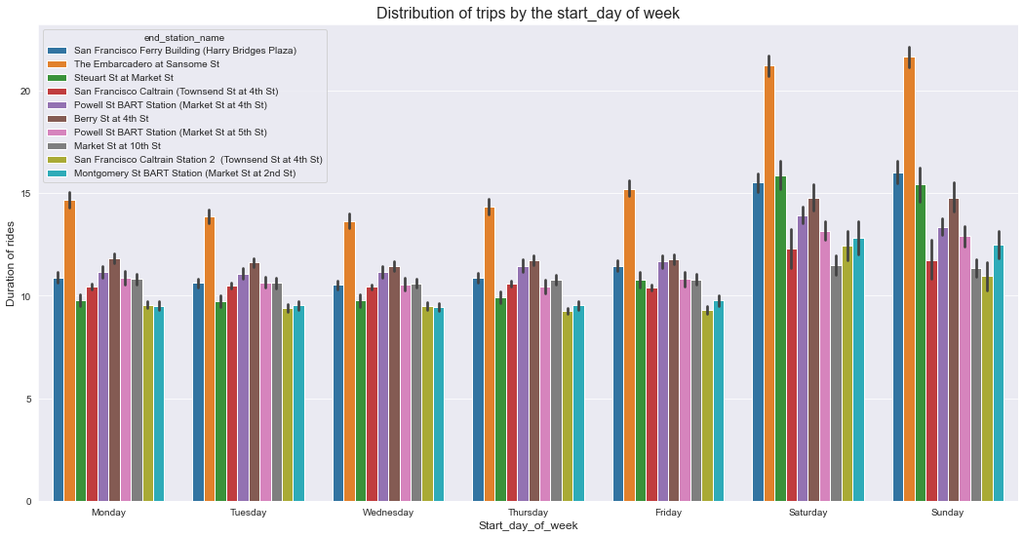

```python
plt.figure(figsize=(18,9))
base_color = sb.color_palette()[1]

weekday = ['Monday', 'Tuesday', 'Wednesday', 'Thursday', 'Friday', 'Saturday', 'Sunday']
weekdaycat = pd.api.types.CategoricalDtype(ordered=True, categories=weekday)
top_dest_df['start_day_of_week'] = top_dest_df['start_day_of_week'].astype(weekdaycat)

sb.barplot(data=top_dest_df, x='start_day_of_week', y='duration_min', hue='end_station_name')
plt.xlabel('Start_day_of_week', fontsize=12)
plt.ylabel('Duration of rides', fontsize=12)
plt.title("Distribution of trips by the start_day of week", fontsize=16);
```

If you check the location `The Embarcadero at Sansome St` you see that the station is really in the middle of a great tourist/recreation area which ... can make you understand why the bike trips by Customers take long... :)

[figure not shown]

```python
from IPython.display import Image
Image(filename='Embarcadero.png')
```